# Startup Prediction

Iryna Popovych, Sofiya Hevorhyan

April 2019

*This project is a second-year semester work on course “Linear Algebra”. The aim of this research is to predict whether the startup will be successful or not with the highest accuracy, based on different criteria. Because of this purpose were used a couple of different methods for variable selection along with Principal Component Analysis, Linear Discriminant Analysis and Support Vector Machine*

## Importing data and recording original variables

### Read data

First of all, we have to read the data and store it in appropriate variables. There are also some further transformation with it, so we add column Category and merge dataset so we will not perform the same actions twice

```r
set.seed(500)

# importing train and test data
train <- read.csv(file="./data/CAX_Startup_Train.csv", header=TRUE,as.is=T)
test <- read.csv(file="./data/CAX_Startup_Test.csv", header=TRUE,as.is=T)
train$Category <- c("Train")
test$Category <- c("Test")

# row binding imported train and test data
merged <- rbind(train,test)
```

### Exploring and retyping

We can see that some variables in our data should be retyped. We divide all the variables in categories: 1) numerical or integer class, as representation of numbers info, rounded to 4 2) multi-stage factors, as categorical variable 3) 1/0 integer values as dummy variables 4) CAX_id and dependent variable

```r
my.to.factor <- function(x) {
  new.col <- as.factor(x)
  return(new.col)
}

my.to.dummy <- function(x) {
  x <- factor(x, levels=c("No", "Yes"))
  x <- as.numeric(x)-1
  return(x)
}

my.to.number <- function(x) {
  new.column <- round(x, 4)
  return(new.column)
}

my.retype.func <- function(merged) {
  my.names <- names(merged)
  my.cnt.names <- c()
  my.fact.names <- c()

  # skip CAX_id and dependent var
  for (i in 3:ncol(merged)) {
    col.class <- class(merged[, i])
    col <- merged[, i]

    if (col.class == "numeric") {
      merged[, i] <- my.to.number(col)
      my.cnt.names <- c(my.cnt.names, my.names[i])

    } else if (col.class == "character" && unique(col) %in% c("No", "Yes")) {
      merged[, i] <- my.to.dummy(col)
      my.cnt.names <- c(my.cnt.names, my.names[i])

    } else if (col.class == "character") {
      merged[, i] <- my.to.factor(merged[, i])
      my.fact.names <- c(my.fact.names, my.names[i])

    } else {
      my.cnt.names <- c(my.cnt.names, my.names[i])
    }
  }
  result <- list()
  result$merged <- merged
  result$my.names <- my.names
  result$my.cnt.names <- my.cnt.names
  result$my.fct.names <- my.fact.names

  return(result)
}
```

Retyping some of the variables by different functions

```r
# Note: now all variables are either factors or numbers (except cax_id, 1 col)
# dependent variable is still of type numeric
# names of factor/num col see in result$my.....
result <- my.retype.func(merged)
merged <- result$merged
head(merged)
```

|  | CAX_ID | Dependent | Company_Location | Company_raising_fund | Company_Industry_count | Company_mobile_app | Company_investor_count_seed | Company_investor_count_Angel_VC | Company_cofounders_count | Company_advisors_count | Company_senior_team_count | Company_top_Angel_VC_funding | Company_repeat_investors_count | Founders_top_company_experience | Founders_previous_company_employee_count | Founders_startup_experience | Founders_big_5_experience | Company_business_model | Founders_experience | Founders_global_exposure | Founders_Industry_exposure | Founder_education | Founder_university_quality | Founders_Popularity | Founders_fortune1000_company_score | Founders_profile_similarity | Founders_publications | Founders_skills_score | Founders_Entrepreneurship_skills_score | … |
| --- | --- | --- | --- | --- | --- | --- | --- | --- | --- | --- | --- | --- | --- | --- | --- | --- | --- | --- | --- | --- | --- | --- | --- | --- | --- | --- | --- | --- | --- | --- |
| 1 | Company2 | 1 | USA | 0 | Few | 1 | 5 | 0 | 2 | 0 | 4 | 0 | 0 | 1 | Large | 1 | 0 | B2C | High | 1 | High | Masters | 4 | 1 | 0.0 | Medium | None | 34.0 | 15.8824 | … |
| 2 | Company3 | 1 | USA | 0 | Few | 0 | 15 | 0 | 3 | 0 | 7 | 0 | 0 | 1 | Medium | 0 | 0 | B2B | Medium | 1 | Low | Bachelors | 1 | 1 | 0.2 | Medium | None | 36.0 | 9.4017 | … |
| 3 | Company5 | 1 | USA | 0 | Few | 0 | 7 | 0 | 1 | 1 | 8 | 0 | 0 | 0 | Small | 0 | 0 | B2B | High | 1 | Medium | Bachelors | 0 | 1 | 0.0 | Low | Few | 23.0 | 0.0000 | … |
| 4 | Company6 | 1 | USA | 0 | Few | 0 | 2 | 0 | 4 | 0 | 4 | 0 | 2 | 0 | Medium | 0 | 0 | Both | High | 1 | Medium | Masters | 0 | 1 | 0.0 | Low | None | 25.0 | 6.2500 | … |
| 5 | Company8 | 1 | USA | 0 | Few | 0 | 0 | 0 | 3 | 4 | 4 | 0 | 0 | 0 | Large | 1 | 0 | B2B | High | 1 | Medium | Masters | 4 | 1 | 0.0 | High | Few | 4.5 | 0.0000 | … |
| 6 | Company9 | 1 | USA | 0 | Few | 0 | 13 | 0 | 2 | 0 | 2 | 0 | 0 | 1 | Medium | 1 | 0 | B2B | High | 1 | High | Masters | 4 | 1 | 0.0 | Medium | None | 48.0 | 8.3333 | … |

```r
my.names <- result$my.names
```

## Making Your own test data

To perform different analysis we have splitted our train data into two sets - train_new to train our models (using different methods) and to test them with test_new (as in original test we don’t have real values of Dependent column)

```r
library(caTools)

my.split <- function(merged) {
  # for return
  result <- list()

  train <- merged[merged$Category == "Train",]
  test <- merged[merged$Category == "Test",]
  train$Category <- NULL
  test$Category <- NULL

  result$test <- test
  result$train <- train

  # partitioning of test and train set for own evaluation of models
  # seprating out 0 and 1 level
  train_0 <- train[train$Dependent==0,]
  train_1 <- train[train$Dependent==1,]

  # randomly choosing test and train set for each level
  sample_0 = sample.split(train_0, SplitRatio = .9)
  train_0_new = subset(train_0, sample_0 == TRUE)
  test_0_new = subset(train_0, sample_0 == FALSE)

  sample_1 = sample.split(train_1, SplitRatio = .9)
  train_1_new = subset(train_1, sample_1 == TRUE)
  test_1_new = subset(train_1, sample_1 == FALSE)

  # final new train and test set
  result$train_new <- rbind(train_1_new,train_0_new)
  result$test_new <- rbind(test_1_new,test_0_new)

  return(result)
}

splitted <- my.split(merged)
test <- splitted$test
train <- splitted$train
train_new <- splitted$train_new
test_new <- splitted$test_new
```

## Graphics

After retyping and transformation, we tried to play with data to understand it better and reveal some of our intuitive ideas and predictions that might have some effect in our analysis

```r
# install.packages('ggvis')
library(ggvis)
library(ggplot2)

# first plot, scatter
train %>% ggvis(~Founders_skills_score, ~Company_senior_team_count, fill = ~Dependent) %>% layer_points()
```

[output not shown]

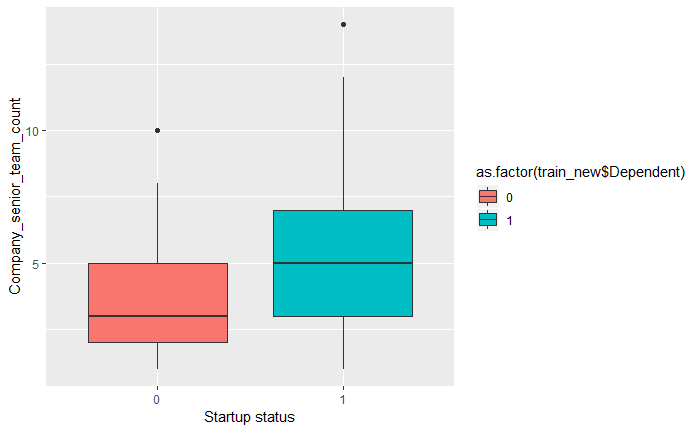

```r
# second plot
ggplot(train_new,
       aes(x=as.factor(train_new$Dependent),
           y=Company_senior_team_count,
                   fill=as.factor(train_new$Dependent))) +
  xlab("Startup status") +
  geom_boxplot()
```

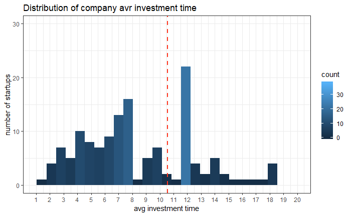

```r
# third plot
ggplot(train_new, aes(x=train_new$Company_avg_investment_time)) +
  geom_histogram(aes(fill=..count..), binwidth = 0.7) +
  scale_x_continuous(name="avg investment time",
                     breaks=seq(1, 20, by=1), limits=c(1, 20)) +
  scale_y_continuous(name="number of startups", limits=c(0,30)) +
  ggtitle("Distribution of company avr investment time") +
  theme_bw() +
  geom_vline(xintercept = mean(train_new$Company_avg_investment_time), size = 1,
             colour = "#FF3721",
             linetype = "dashed")
```

## Variable selection

One last data transformation

```r
# to not spoil the data
train_new$CAX_ID <- NULL
test_new$CAX_ID <- NULL

library(dummies)
# before moving to var selecion
# create data frame with dummy variables and all numerical
# now that's all independent variables
pca.train <- dummy.data.frame(subset(train_new, select = -Dependent), names = result$my.fct.names)
pca.test <- dummy.data.frame(subset(test_new, select = -Dependent), names = result$my.fct.names)
pca.test.final <- dummy.data.frame(subset(test, select = -Dependent), names = result$my.fct.names)
# names(pca.test.final)[!names(pca.test.final) %in% names(pca.test)]

# now we have 75 variables including dummies
pca.train
```

|  | Company_LocationEurope | Company_LocationOther | Company_LocationUSA | Company_raising_fund | Company_Industry_countFew | Company_Industry_countMany | Company_Industry_countsingle | Company_mobile_app | Company_investor_count_seed | Company_investor_count_Angel_VC | Company_cofounders_count | Company_advisors_count | Company_senior_team_count | Company_top_Angel_VC_funding | Company_repeat_investors_count | Founders_top_company_experience | Founders_previous_company_employee_countLarge | Founders_previous_company_employee_countMedium | Founders_previous_company_employee_countSmall | Founders_startup_experience | Founders_big_5_experience | Company_business_modelB2B | Company_business_modelB2C | Company_business_modelBoth | Founders_experienceHigh | Founders_experienceLow | Founders_experienceMedium | Founders_global_exposure | Founders_Industry_exposureHigh | … |
| --- | --- | --- | --- | --- | --- | --- | --- | --- | --- | --- | --- | --- | --- | --- | --- | --- | --- | --- | --- | --- | --- | --- | --- | --- | --- | --- | --- | --- | --- | --- |
| 2 | 0 | 0 | 1 | 0 | 1 | 0 | 0 | 0 | 15 | 0 | 3 | 0 | 7 | 0 | 0 | 1 | 0 | 1 | 0 | 0 | 0 | 1 | 0 | 0 | 0 | 0 | 1 | 1 | 0 | … |
| 3 | 0 | 0 | 1 | 0 | 1 | 0 | 0 | 0 | 7 | 0 | 1 | 1 | 8 | 0 | 0 | 0 | 0 | 0 | 1 | 0 | 0 | 1 | 0 | 0 | 1 | 0 | 0 | 1 | 0 | … |
| 4 | 0 | 0 | 1 | 0 | 1 | 0 | 0 | 0 | 2 | 0 | 4 | 0 | 4 | 0 | 2 | 0 | 0 | 1 | 0 | 0 | 0 | 0 | 0 | 1 | 1 | 0 | 0 | 1 | 0 | … |
| 5 | 0 | 0 | 1 | 0 | 1 | 0 | 0 | 0 | 0 | 0 | 3 | 4 | 4 | 0 | 0 | 0 | 1 | 0 | 0 | 1 | 0 | 1 | 0 | 0 | 1 | 0 | 0 | 1 | 0 | … |
| 6 | 0 | 0 | 1 | 0 | 1 | 0 | 0 | 0 | 13 | 0 | 2 | 0 | 2 | 0 | 0 | 1 | 0 | 1 | 0 | 1 | 0 | 1 | 0 | 0 | 1 | 0 | 0 | 1 | 1 | … |
| 7 | 0 | 0 | 1 | 0 | 1 | 0 | 0 | 0 | 0 | 0 | 2 | 1 | 8 | 0 | 0 | 0 | 0 | 0 | 1 | 1 | 0 | 1 | 0 | 0 | 1 | 0 | 0 | 1 | 1 | … |
| 9 | 0 | 0 | 1 | 0 | 1 | 0 | 0 | 0 | 0 | 0 | 3 | 0 | 6 | 0 | 0 | 0 | 1 | 0 | 0 | 1 | 1 | 1 | 0 | 0 | 0 | 0 | 1 | 1 | 0 | … |
| 11 | 0 | 0 | 1 | 0 | 1 | 0 | 0 | 0 | 0 | 0 | 2 | 0 | 8 | 0 | 0 | 0 | 0 | 0 | 1 | 0 | 0 | 1 | 0 | 0 | 1 | 0 | 0 | 1 | 0 | … |
| 12 | 0 | 0 | 1 | 0 | 0 | 0 | 1 | 0 | 0 | 3 | 1 | 0 | 7 | 0 | 2 | 0 | 0 | 0 | 1 | 0 | 0 | 1 | 0 | 0 | 1 | 0 | 0 | 1 | 1 | … |
| 13 | 0 | 0 | 1 | 0 | 0 | 0 | 1 | 0 | 0 | 0 | 3 | 0 | 8 | 0 | 2 | 0 | 0 | 0 | 1 | 0 | 0 | 1 | 0 | 0 | 1 | 0 | 0 | 1 | 0 | … |

[output cut: 194 more lines]

```r
pca.test
```

|  | Company_LocationEurope | Company_LocationUSA | Company_raising_fund | Company_Industry_countFew | Company_Industry_countMany | Company_Industry_countsingle | Company_mobile_app | Company_investor_count_seed | Company_investor_count_Angel_VC | Company_cofounders_count | Company_advisors_count | Company_senior_team_count | Company_top_Angel_VC_funding | Company_repeat_investors_count | Founders_top_company_experience | Founders_previous_company_employee_countLarge | Founders_previous_company_employee_countMedium | Founders_previous_company_employee_countSmall | Founders_startup_experience | Founders_big_5_experience | Company_business_modelB2B | Company_business_modelB2C | Company_business_modelBoth | Founders_experienceHigh | Founders_experienceLow | Founders_experienceMedium | Founders_global_exposure | Founders_Industry_exposureHigh | Founders_Industry_exposureLow | … |
| --- | --- | --- | --- | --- | --- | --- | --- | --- | --- | --- | --- | --- | --- | --- | --- | --- | --- | --- | --- | --- | --- | --- | --- | --- | --- | --- | --- | --- | --- | --- |
| 1 | 0 | 1 | 0 | 1 | 0 | 0 | 1 | 5 | 0 | 2 | 0 | 4 | 0 | 0 | 1 | 1 | 0 | 0 | 1 | 0 | 0 | 1 | 0 | 1 | 0 | 0 | 1 | 1 | 0 | … |
| 8 | 0 | 1 | 0 | 1 | 0 | 0 | 0 | 0 | 0 | 0 | 1 | 8 | 0 | 1 | 0 | 0 | 1 | 0 | 1 | 0 | 1 | 0 | 0 | 1 | 0 | 0 | 1 | 0 | 0 | … |
| 16 | 0 | 1 | 0 | 0 | 0 | 1 | 0 | 0 | 0 | 2 | 0 | 4 | 0 | 0 | 0 | 0 | 1 | 0 | 1 | 1 | 1 | 0 | 0 | 1 | 0 | 0 | 1 | 1 | 0 | … |
| 38 | 0 | 1 | 0 | 0 | 0 | 1 | 0 | 10 | 0 | 1 | 3 | 4 | 1 | 2 | 0 | 0 | 1 | 0 | 0 | 0 | 0 | 0 | 1 | 0 | 0 | 1 | 0 | 0 | 1 | … |
| 39 | 0 | 1 | 0 | 0 | 0 | 1 | 0 | 3 | 0 | 2 | 2 | 3 | 1 | 1 | 0 | 0 | 1 | 0 | 0 | 0 | 1 | 0 | 0 | 1 | 0 | 0 | 1 | 1 | 0 | … |
| 75 | 0 | 1 | 0 | 0 | 0 | 1 | 0 | 0 | 0 | 1 | 7 | 9 | 0 | 2 | 0 | 1 | 0 | 0 | 1 | 0 | 1 | 0 | 0 | 0 | 0 | 1 | 1 | 0 | 1 | … |
| 99 | 0 | 1 | 0 | 1 | 0 | 0 | 0 | 0 | 0 | 1 | 6 | 5 | 0 | 0 | 0 | 0 | 1 | 0 | 1 | 0 | 1 | 0 | 0 | 0 | 0 | 1 | 1 | 0 | 0 | … |
| 110 | 0 | 1 | 0 | 1 | 0 | 0 | 0 | 1 | 2 | 3 | 3 | 8 | 0 | 2 | 1 | 1 | 0 | 0 | 0 | 0 | 1 | 0 | 0 | 0 | 0 | 1 | 1 | 0 | 1 | … |
| 143 | 0 | 1 | 0 | 0 | 0 | 1 | 0 | 0 | 0 | 4 | 8 | 8 | 1 | 4 | 0 | 0 | 1 | 0 | 1 | 0 | 1 | 0 | 0 | 0 | 0 | 1 | 0 | 0 | 1 | … |
| 188 | 0 | 1 | 0 | 0 | 1 | 0 | 0 | 1 | 0 | 4 | 0 | 7 | 1 | 0 | 1 | 0 | 1 | 0 | 1 | 0 | 1 | 0 | 0 | 1 | 0 | 0 | 1 | 0 | 1 | … |

[output cut: 20 more lines]

```r
# here we select only those columns for training which we have in test, it it the pre-requirement for the model
pca.train <- subset(pca.train, select=c(colnames(pca.test)))
pca.test.final <- subset(pca.test.final, select=c(colnames(pca.test), "CAX_ID"))
# now train has the same numer of columns as test
pca.train
```

|  | Company_LocationEurope | Company_LocationUSA | Company_raising_fund | Company_Industry_countFew | Company_Industry_countMany | Company_Industry_countsingle | Company_mobile_app | Company_investor_count_seed | Company_investor_count_Angel_VC | Company_cofounders_count | Company_advisors_count | Company_senior_team_count | Company_top_Angel_VC_funding | Company_repeat_investors_count | Founders_top_company_experience | Founders_previous_company_employee_countLarge | Founders_previous_company_employee_countMedium | Founders_previous_company_employee_countSmall | Founders_startup_experience | Founders_big_5_experience | Company_business_modelB2B | Company_business_modelB2C | Company_business_modelBoth | Founders_experienceHigh | Founders_experienceLow | Founders_experienceMedium | Founders_global_exposure | Founders_Industry_exposureHigh | Founders_Industry_exposureLow | … |
| --- | --- | --- | --- | --- | --- | --- | --- | --- | --- | --- | --- | --- | --- | --- | --- | --- | --- | --- | --- | --- | --- | --- | --- | --- | --- | --- | --- | --- | --- | --- |
| 2 | 0 | 1 | 0 | 1 | 0 | 0 | 0 | 15 | 0 | 3 | 0 | 7 | 0 | 0 | 1 | 0 | 1 | 0 | 0 | 0 | 1 | 0 | 0 | 0 | 0 | 1 | 1 | 0 | 1 | … |
| 3 | 0 | 1 | 0 | 1 | 0 | 0 | 0 | 7 | 0 | 1 | 1 | 8 | 0 | 0 | 0 | 0 | 0 | 1 | 0 | 0 | 1 | 0 | 0 | 1 | 0 | 0 | 1 | 0 | 0 | … |
| 4 | 0 | 1 | 0 | 1 | 0 | 0 | 0 | 2 | 0 | 4 | 0 | 4 | 0 | 2 | 0 | 0 | 1 | 0 | 0 | 0 | 0 | 0 | 1 | 1 | 0 | 0 | 1 | 0 | 0 | … |
| 5 | 0 | 1 | 0 | 1 | 0 | 0 | 0 | 0 | 0 | 3 | 4 | 4 | 0 | 0 | 0 | 1 | 0 | 0 | 1 | 0 | 1 | 0 | 0 | 1 | 0 | 0 | 1 | 0 | 0 | … |
| 6 | 0 | 1 | 0 | 1 | 0 | 0 | 0 | 13 | 0 | 2 | 0 | 2 | 0 | 0 | 1 | 0 | 1 | 0 | 1 | 0 | 1 | 0 | 0 | 1 | 0 | 0 | 1 | 1 | 0 | … |
| 7 | 0 | 1 | 0 | 1 | 0 | 0 | 0 | 0 | 0 | 2 | 1 | 8 | 0 | 0 | 0 | 0 | 0 | 1 | 1 | 0 | 1 | 0 | 0 | 1 | 0 | 0 | 1 | 1 | 0 | … |
| 9 | 0 | 1 | 0 | 1 | 0 | 0 | 0 | 0 | 0 | 3 | 0 | 6 | 0 | 0 | 0 | 1 | 0 | 0 | 1 | 1 | 1 | 0 | 0 | 0 | 0 | 1 | 1 | 0 | 1 | … |
| 11 | 0 | 1 | 0 | 1 | 0 | 0 | 0 | 0 | 0 | 2 | 0 | 8 | 0 | 0 | 0 | 0 | 0 | 1 | 0 | 0 | 1 | 0 | 0 | 1 | 0 | 0 | 1 | 0 | 0 | … |
| 12 | 0 | 1 | 0 | 0 | 0 | 1 | 0 | 0 | 3 | 1 | 0 | 7 | 0 | 2 | 0 | 0 | 0 | 1 | 0 | 0 | 1 | 0 | 0 | 1 | 0 | 0 | 1 | 1 | 0 | … |
| 13 | 0 | 1 | 0 | 0 | 0 | 1 | 0 | 0 | 0 | 3 | 0 | 8 | 0 | 2 | 0 | 0 | 0 | 1 | 0 | 0 | 1 | 0 | 0 | 1 | 0 | 0 | 1 | 0 | 0 | … |

[output cut: 194 more lines]

```r
data.train.all <- cbind(pca.train, as.factor(train_new$Dependent))
data.test.all <- cbind(pca.test, as.factor(test_new$Dependent))
data.test.final <- cbind(pca.test.final, as.factor(test$Dependent))
names(data.train.all)[75] <- "Dependent"
names(data.test.all)[75] <- "Dependent"
names(data.test.final)[76] <- "Dependent"
levels(data.train.all$Dependent) <- c("fail", "success")
levels(data.test.all$Dependent) <- c("fail", "success")
levels(data.test.final$Dependent) <- c("fail", "success")
```

### using information value

First, we try to select some important variables using information value method. We will remove CAX_id column so it will not influence our results as only dependent and independent variables should be included in data frame Information Value for logistic regression is analogous to correlation for linear regression. It tells us how well an independent variable is able to distinguish two categories of dependent variables

```r
# install.packages("devtools")
library(devtools)
# install_github("tomasgreif/woe")
library(woe)

# calculation of information value
row.names(data.train.all) <- 1:nrow(data.train.all)
IV <- iv.mult(data.train.all,y="Dependent",TRUE)
```

[output not shown]

[output cut: 19 more lines]

[output not shown]

```r
# selecting variables with 0.1 < IV < 0.5
var1 <- IV[which(IV$InformationValue>0.1),]
var1 <- c(var1, var1[which(var1$InformationValue<0.5),])
x_train <- data.train.all[var1$Variable]
Dependent <- data.train.all$Dependent

# final df with important variables
train.iv <- cbind(Dependent,x_train)
as.data.frame(train.iv)
```

|  | Dependent | Company_senior_team_count | Founders_skills_score | Company_business_modelB2C | Company_avg_investment_time | Company_business_modelB2B | Founders_Marketing_skills_score | Founders_Entrepreneurship_skills_score | Company_repeat_investors_count | Founders_Sales_skills_score | Company_competitor_count | Company_analytics_score | Founders_Data_Science_skills_score | Company_1st_investment_time | Company_investor_count_seed | Founders_Engineering_skills_score | Founders_Product_Management_skills_score | Founders_Business_Strategy_skills_score | Founders_Domain_skills_score | Founders_Industry_exposureHigh | Founders_profile_similarityNone | Founders_global_exposure |
| --- | --- | --- | --- | --- | --- | --- | --- | --- | --- | --- | --- | --- | --- | --- | --- | --- | --- | --- | --- | --- | --- | --- |
| 1 | success | 7 | 36.0 | 0 | 7.3444 | 1 | 0.0000 | 9.4017 | 0 | 0.0000 | 0 | 1 | 3.8462 | 2 | 15 | 57.4786 | 9.4017 | 17.0940 | 2.7778 | 0 | 0 | 1 |
| 2 | success | 8 | 23.0 | 0 | 9.8222 | 1 | 0.0000 | 0.0000 | 0 | 0.0000 | 0 | 0 | 0.0000 | 13 | 7 | 0.0000 | 0.0000 | 0.0000 | 0.0000 | 0 | 0 | 1 |
| 3 | success | 4 | 25.0 | 0 | 9.3222 | 0 | 15.6250 | 6.2500 | 2 | 3.1250 | 0 | 0 | 3.1250 | 12 | 2 | 3.1250 | 3.1250 | 6.2500 | 0.0000 | 0 | 0 | 1 |
| 4 | success | 4 | 4.5 | 0 | 6.4000 | 1 | 0.0000 | 0.0000 | 0 | 0.0000 | 0 | 2 | 0.0000 | 20 | 0 | 10.1120 | 0.0000 | 0.0000 | 0.0000 | 0 | 0 | 1 |
| 5 | success | 2 | 48.0 | 0 | 12.0000 | 1 | 5.7190 | 8.3333 | 0 | 2.7778 | 0 | 0 | 0.0000 | 18 | 13 | 46.7320 | 2.7778 | 19.7712 | 0.0000 | 1 | 0 | 1 |
| 6 | success | 8 | 14.5 | 0 | 2.6667 | 1 | 0.0000 | 3.8462 | 0 | 3.8462 | 4 | 0 | 3.8462 | 24 | 0 | 26.9231 | 0.0000 | 7.6923 | 0.0000 | 1 | 1 | 1 |
| 7 | success | 6 | 20.5 | 0 | 7.3333 | 1 | 16.6667 | 8.3333 | 0 | 4.1667 | 0 | 0 | 12.5000 | 14 | 0 | 50.0000 | 4.1667 | 4.1667 | 0.0000 | 0 | 0 | 1 |
| 8 | success | 8 | 21.0 | 0 | 8.0000 | 1 | 0.0000 | 11.1111 | 0 | 11.1111 | 0 | 1 | 11.1111 | 38 | 0 | 5.5556 | 0.0000 | 27.7778 | 5.5556 | 0 | 0 | 1 |
| 9 | success | 7 | 12.0 | 0 | 11.0667 | 1 | 0.0000 | 8.3333 | 2 | 0.0000 | 0 | 1 | 0.0000 | 3 | 0 | 58.3333 | 0.0000 | 25.0000 | 8.3333 | 1 | 1 | 1 |
| 10 | success | 8 | 4.5 | 0 | 12.6167 | 1 | 0.0000 | 20.0000 | 2 | 0.0000 | 0 | 3 | 0.0000 | 30 | 0 | 20.0000 | 0.0000 | 20.0000 | 0.0000 | 0 | 0 | 1 |

[output cut: 194 more lines]

### using randomForest

Another methods for variables selection are randomForest and variable importance from caret package. Random Forest is one of the most popular classification algoritms. Our goal is to pick up some relevant features that will classify our Dependent variable well.

```r
# generate summary
fit_glm=glm(Dependent~.,data.train.all,family = "binomial")
summary(fit_glm)
```

```
Call:
glm(formula = Dependent ~ ., family = "binomial", data = data.train.all)

Deviance Residuals:
     Min        1Q    Median        3Q       Max
-2.04201  -0.63730  -0.00005   0.63755   2.27951

Coefficients: (12 not defined because of singularities)
                                                 Estimate Std. Error z value Pr(>|z|)
(Intercept)                                    -4.765e+00  2.364e+00  -2.016 0.043796 *
Company_LocationEurope                          3.833e-01  1.391e+00   0.276 0.782873
Company_LocationUSA                            -2.011e+00  1.328e+00  -1.514 0.129984
Company_raising_fund                           -2.225e+01  1.038e+03  -0.021 0.982894
Company_Industry_countFew                      -5.165e-01  5.508e-01  -0.938 0.348388
Company_Industry_countMany                      1.265e-01  8.033e-01   0.157 0.874911
Company_Industry_countsingle                           NA         NA      NA       NA
Company_mobile_app                              3.683e+00  1.674e+00   2.200 0.027808 *
Company_investor_count_seed                    -1.969e-02  8.978e-02  -0.219 0.826428
Company_investor_count_Angel_VC                -6.039e-02  1.351e-01  -0.447 0.654854
Company_cofounders_count                        2.512e-01  2.365e-01   1.062 0.288018
Company_advisors_count                         -7.521e-02  1.387e-01  -0.542 0.587754
Company_senior_team_count                       3.676e-01  1.291e-01   2.848 0.004405 **
Company_top_Angel_VC_funding                    4.620e-01  6.411e-01   0.721 0.471071
Company_repeat_investors_count                  1.883e-01  2.245e-01   0.839 0.401536
Founders_top_company_experience                -1.254e+00  7.475e-01  -1.677 0.093546 .
Founders_previous_company_employee_countLarge  -4.433e-01  6.963e-01  -0.637 0.524362
Founders_previous_company_employee_countMedium -1.161e+00  5.558e-01  -2.089 0.036711 *
Founders_previous_company_employee_countSmall          NA         NA      NA       NA
Founders_startup_experience                    -1.838e-01  5.073e-01  -0.362 0.717139
Founders_big_5_experience                       3.383e+00  1.655e+00   2.044 0.040960 *
Company_business_modelB2B                      -2.735e-01  1.326e+00  -0.206 0.836550
Company_business_modelB2C                      -2.242e+00  1.435e+00  -1.563 0.118076
Company_business_modelBoth                             NA         NA      NA       NA
Founders_experienceHigh                         9.496e-01  5.616e-01   1.691 0.090874 .
Founders_experienceLow                         -3.762e+00  2.039e+00  -1.845 0.065063 .
Founders_experienceMedium                              NA         NA      NA       NA
Founders_global_exposure                        5.409e-01  6.005e-01   0.901 0.367790
Founders_Industry_exposureHigh                  4.108e-01  9.022e-01   0.455 0.648916
Founders_Industry_exposureLow                   4.839e-01  5.579e-01   0.867 0.385778
Founders_Industry_exposureMedium                       NA         NA      NA       NA
```

[output cut: 39 more lines]

```
Founder_highest_degree_typeTechnology                  NA         NA      NA       NA
Company_difficulty_obtaining_workforceHigh     -1.035e+00  8.893e-01  -1.164 0.244296
Company_difficulty_obtaining_workforceLow       4.551e-02  5.801e-01   0.078 0.937478
Company_difficulty_obtaining_workforceMedium           NA         NA      NA       NA
Company_Founder_Patent                         -9.639e-01  7.850e-01  -1.228 0.219468
---
Signif. codes:  0 ‘***’ 0.001 ‘**’ 0.01 ‘*’ 0.05 ‘.’ 0.1 ‘ ’ 1

(Dispersion parameter for binomial family taken to be 1)

    Null deviance: 282.78  on 203  degrees of freedom
Residual deviance: 161.60  on 141  degrees of freedom
AIC: 287.6

Number of Fisher Scoring iterations: 15
```

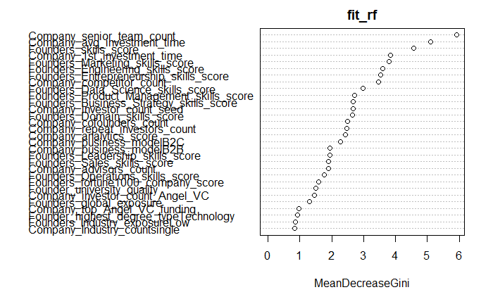

```r
# Using varImp() function
library(caret)
importance1 <- varImp(fit_glm)

#Import the random forest library and fit a model
library(randomForest)
fit_rf=randomForest(Dependent~., data=data.train.all)

# Create an importance based on mean decreasing gini
importance2 <- importance(fit_rf)

# Create a plot of importance scores by random forest
varImpPlot(fit_rf)
```

```r
# select variables for second model
# 2.5 as a key point before sharp decline (top-7 variables)
var2 <- rownames(importance1)[which(importance1$Overall > 2.4)]
# var2[var2 == "Founders_publicationsNone"] <- "Founders_publications"
# var2[var2 == "Company_LocationUSA"] <- "Company_Location"
# var2[var2 == "Founder_educationMasters"] <- "Founder_education"
# var2[var2 == "Company_business_modelB2C"] <- "Company_business_model"
var2 <- c(var2, rownames(importance2)[which(importance2 > 3)])

# final df from rf
train.varimp <- cbind(Dependent, data.train.all[,var2])
as.data.frame(train.varimp)
```

|  | Dependent | Company_senior_team_count | Founders_Popularity | Founders_publicationsFew | Founders_Data_Science_skills_score | Company_crowdfunding | Company_subscription_offering | Company_senior_team_count.1 | Founders_skills_score | Founders_Entrepreneurship_skills_score | Founders_Engineering_skills_score | Founders_Marketing_skills_score | Company_competitor_count | Company_1st_investment_time | Company_avg_investment_time |
| --- | --- | --- | --- | --- | --- | --- | --- | --- | --- | --- | --- | --- | --- | --- | --- |
| 1 | success | 7 | 1 | 0 | 3.8462 | 0 | 1 | 7 | 36.0 | 9.4017 | 57.4786 | 0.0000 | 0 | 2 | 7.3444 |
| 2 | success | 8 | 1 | 1 | 0.0000 | 0 | 0 | 8 | 23.0 | 0.0000 | 0.0000 | 0.0000 | 0 | 13 | 9.8222 |
| 3 | success | 4 | 1 | 0 | 3.1250 | 0 | 0 | 4 | 25.0 | 6.2500 | 3.1250 | 15.6250 | 0 | 12 | 9.3222 |
| 4 | success | 4 | 1 | 1 | 0.0000 | 0 | 0 | 4 | 4.5 | 0.0000 | 10.1120 | 0.0000 | 0 | 20 | 6.4000 |
| 5 | success | 2 | 1 | 0 | 0.0000 | 0 | 0 | 2 | 48.0 | 8.3333 | 46.7320 | 5.7190 | 0 | 18 | 12.0000 |
| 6 | success | 8 | 1 | 0 | 3.8462 | 0 | 0 | 8 | 14.5 | 3.8462 | 26.9231 | 0.0000 | 4 | 24 | 2.6667 |
| 7 | success | 6 | 1 | 0 | 12.5000 | 0 | 1 | 6 | 20.5 | 8.3333 | 50.0000 | 16.6667 | 0 | 14 | 7.3333 |
| 8 | success | 8 | 1 | 1 | 11.1111 | 0 | 0 | 8 | 21.0 | 11.1111 | 5.5556 | 0.0000 | 0 | 38 | 8.0000 |
| 9 | success | 7 | 0 | 1 | 0.0000 | 0 | 0 | 7 | 12.0 | 8.3333 | 58.3333 | 0.0000 | 0 | 3 | 11.0667 |
| 10 | success | 8 | 1 | 1 | 0.0000 | 0 | 0 | 8 | 4.5 | 20.0000 | 20.0000 | 0.0000 | 0 | 30 | 12.6167 |

[output cut: 194 more lines]

### using Mars

MARS is another way to pick up variables for our regression. It implements variable importance based on Generalized cross validation (GCV), number of subset models the variable occurs (nsubsets) and residual sum of squares (RSS).

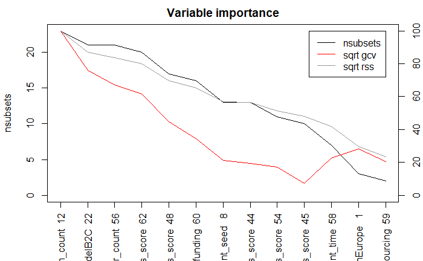

```r
library(earth)
mars.model <- earth(Dependent ~., data=data.train.all)
ev <- evimp(mars.model)

# for this moment not in very appropriate form
plot(x=ev,
    cex.var = 1,
    type.nsubsets = "l", col.nsubsets = "black", lty.nsubsets = 1,
    type.gcv = "l", col.gcv = 2, lty.gcv = 1,
    type.rss = "l", col.rss = "gray60", lty.rss = 1,
    cex.legend = 1, x.legend = nrow(ev), y.legend = ev[1,"nsubsets"],
    rh.col = 1, do.par = F)
```

```r
var3 <- rownames(ev)

# var3[var3 == "Company_business_modelB2C"] <- "Company_business_model"
# var3[var3 == "Founders_skills_score-unused"] <- "Founders_skills_score"
# var2[var2 == "Founders_publicationsNone"] <- "Founders_publications"
# var3[var3 == "Founder_educationMasters"] <- "Founder_education"
# var3[var3 == "Company_crowdfunding-unused"] <- "Company_crowdfunding"

#final df from mars
train.mars <- cbind(Dependent, data.train.all[, var3])
as.data.frame(train.mars)
```

|  | Dependent | Company_senior_team_count | Company_business_modelB2C | Company_competitor_count | Company_analytics_score | Founders_Marketing_skills_score | Company_crowdfunding | Company_investor_count_seed | Founders_skills_score | Founders_Domain_skills_score | Founders_Entrepreneurship_skills_score | Company_avg_investment_time | Company_LocationEurope | Company_crowdsourcing |
| --- | --- | --- | --- | --- | --- | --- | --- | --- | --- | --- | --- | --- | --- | --- |
| 1 | success | 7 | 0 | 0 | 1 | 0.0000 | 0 | 15 | 36.0 | 2.7778 | 9.4017 | 7.3444 | 0 | 0 |
| 2 | success | 8 | 0 | 0 | 0 | 0.0000 | 0 | 7 | 23.0 | 0.0000 | 0.0000 | 9.8222 | 0 | 0 |
| 3 | success | 4 | 0 | 0 | 0 | 15.6250 | 0 | 2 | 25.0 | 0.0000 | 6.2500 | 9.3222 | 0 | 0 |
| 4 | success | 4 | 0 | 0 | 2 | 0.0000 | 0 | 0 | 4.5 | 0.0000 | 0.0000 | 6.4000 | 0 | 0 |
| 5 | success | 2 | 0 | 0 | 0 | 5.7190 | 0 | 13 | 48.0 | 0.0000 | 8.3333 | 12.0000 | 0 | 1 |
| 6 | success | 8 | 0 | 4 | 0 | 0.0000 | 0 | 0 | 14.5 | 0.0000 | 3.8462 | 2.6667 | 0 | 0 |
| 7 | success | 6 | 0 | 0 | 0 | 16.6667 | 0 | 0 | 20.5 | 0.0000 | 8.3333 | 7.3333 | 0 | 0 |
| 8 | success | 8 | 0 | 0 | 1 | 0.0000 | 0 | 0 | 21.0 | 5.5556 | 11.1111 | 8.0000 | 0 | 0 |
| 9 | success | 7 | 0 | 0 | 1 | 0.0000 | 0 | 0 | 12.0 | 8.3333 | 8.3333 | 11.0667 | 0 | 0 |
| 10 | success | 8 | 0 | 0 | 3 | 0.0000 | 0 | 0 | 4.5 | 0.0000 | 20.0000 | 12.6167 | 0 | 0 |

[output cut: 194 more lines]

## PCA

### PCA with all data

Let’s first try to perform PCA using all the numerical variables we have, to see whetther our data could be spread into components.

```r
train_new
```

|  | Dependent | Company_Location | Company_raising_fund | Company_Industry_count | Company_mobile_app | Company_investor_count_seed | Company_investor_count_Angel_VC | Company_cofounders_count | Company_advisors_count | Company_senior_team_count | Company_top_Angel_VC_funding | Company_repeat_investors_count | Founders_top_company_experience | Founders_previous_company_employee_count | Founders_startup_experience | Founders_big_5_experience | Company_business_model | Founders_experience | Founders_global_exposure | Founders_Industry_exposure | Founder_education | Founder_university_quality | Founders_Popularity | Founders_fortune1000_company_score | Founders_profile_similarity | Founders_publications | Founders_skills_score | Founders_Entrepreneurship_skills_score | Founders_Operations_skills_score | … |
| --- | --- | --- | --- | --- | --- | --- | --- | --- | --- | --- | --- | --- | --- | --- | --- | --- | --- | --- | --- | --- | --- | --- | --- | --- | --- | --- | --- | --- | --- | --- |
| 2 | 1 | USA | 0 | Few | 0 | 15 | 0 | 3 | 0 | 7 | 0 | 0 | 1 | Medium | 0 | 0 | B2B | Medium | 1 | Low | Bachelors | 1 | 1 | 0.2 | Medium | None | 36.0 | 9.4017 | 0.0000 | … |
| 3 | 1 | USA | 0 | Few | 0 | 7 | 0 | 1 | 1 | 8 | 0 | 0 | 0 | Small | 0 | 0 | B2B | High | 1 | Medium | Bachelors | 0 | 1 | 0.0 | Low | Few | 23.0 | 0.0000 | 0.0000 | … |
| 4 | 1 | USA | 0 | Few | 0 | 2 | 0 | 4 | 0 | 4 | 0 | 2 | 0 | Medium | 0 | 0 | Both | High | 1 | Medium | Masters | 0 | 1 | 0.0 | Low | None | 25.0 | 6.2500 | 0.0000 | … |
| 5 | 1 | USA | 0 | Few | 0 | 0 | 0 | 3 | 4 | 4 | 0 | 0 | 0 | Large | 1 | 0 | B2B | High | 1 | Medium | Masters | 4 | 1 | 0.0 | High | Few | 4.5 | 0.0000 | 0.0000 | … |
| 6 | 1 | USA | 0 | Few | 0 | 13 | 0 | 2 | 0 | 2 | 0 | 0 | 1 | Medium | 1 | 0 | B2B | High | 1 | High | Masters | 4 | 1 | 0.0 | Medium | None | 48.0 | 8.3333 | 0.0000 | … |
| 7 | 1 | USA | 0 | Few | 0 | 0 | 0 | 2 | 1 | 8 | 0 | 0 | 0 | Small | 1 | 0 | B2B | High | 1 | High | Bachelors | 0 | 1 | 0.2 | None | None | 14.5 | 3.8462 | 0.0000 | … |
| 9 | 1 | USA | 0 | Few | 0 | 0 | 0 | 3 | 0 | 6 | 0 | 0 | 0 | Large | 1 | 1 | B2B | Medium | 1 | Low | Bachelors | 4 | 1 | 0.2 | Medium | None | 20.5 | 8.3333 | 0.0000 | … |
| 11 | 1 | USA | 0 | Few | 0 | 0 | 0 | 2 | 0 | 8 | 0 | 0 | 0 | Small | 0 | 0 | B2B | High | 1 | Medium | Masters | 4 | 1 | 0.3 | Low | Few | 21.0 | 11.1111 | 5.5556 | … |
| 12 | 1 | USA | 0 | single | 0 | 0 | 3 | 1 | 0 | 7 | 0 | 2 | 0 | Small | 0 | 0 | B2B | High | 1 | High | Masters | 4 | 0 | 0.0 | None | Few | 12.0 | 8.3333 | 0.0000 | … |
| 13 | 1 | USA | 0 | single | 0 | 0 | 0 | 3 | 0 | 8 | 0 | 2 | 0 | Small | 0 | 0 | B2B | High | 1 | Medium | Masters | 1 | 1 | 0.0 | Low | Few | 4.5 | 20.0000 | 0.0000 | … |

[output cut: 194 more lines]

```r
# principal component analysis
prin_comp <- prcomp(pca.train, scale. = T)
# take a brief look at top components and variables rotation matrix
prin_comp$rotation[1:5, 1:4]
```

```
                                   PC1         PC2         PC3         PC4
Company_LocationEurope      0.13765930 -0.25343134  0.10563111  0.12997988
Company_LocationUSA        -0.16678022  0.20702063 -0.08044322 -0.13329323
Company_raising_fund       -0.04144938 -0.11914274  0.01150366  0.01102774
Company_Industry_countFew   0.04830909 -0.07753545  0.12844937  0.07039667
Company_Industry_countMany  0.01206545 -0.10488940  0.13572488 -0.04404417
```

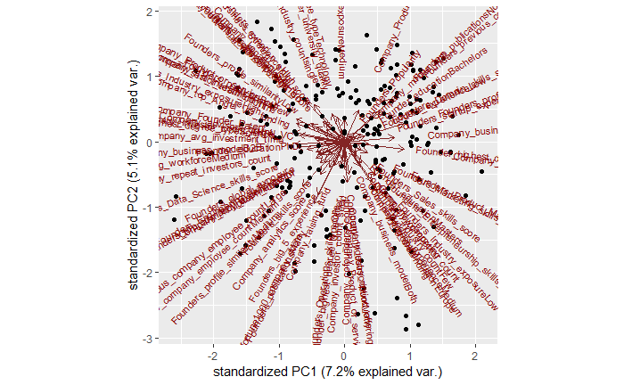

```r
library(ggbiplot)
#plot PCA with vectors
ggbiplot(prin_comp)
```

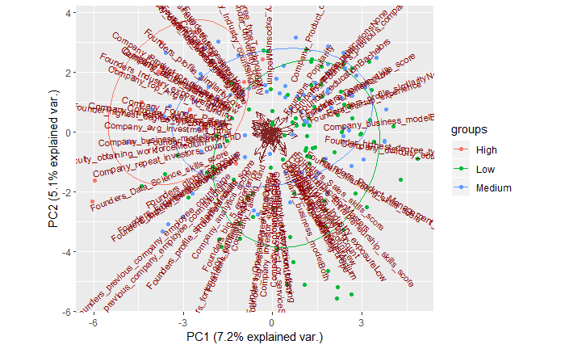

```r
#plot 1st and 2nd principal components grouping by Industry Exposure of Founders
ggbiplot(prin_comp, groups=train_new$Founders_Industry_exposure, scale = 0, ellipse=TRUE)
```

```r
#compute standard deviation of each principal component
std_dev <- prin_comp$sdev

#compute variance
pr_var <- std_dev^2

#proportion of variance explained
prop_varex <- pr_var/sum(pr_var)
prop_varex[1:20]
```

```
 [1] 0.07249000 0.05101382 0.04419743 0.04169759 0.04040559 0.03781266 0.03212066 0.03051413
 [9] 0.02914579 0.02819660 0.02720085 0.02509937 0.02452003 0.02370929 0.02200025 0.02145118
[17] 0.02034738 0.02021775 0.01941978 0.01886484
```

First principal component explains 7.3% variance. Second component explains 5.1% variance. Third component explains 4.4% variance and so on. So, how do we decide how many components should we select for modeling stage?

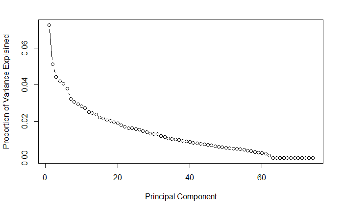

```r
#scree plot
plot(prop_varex, xlab = "Principal Component",
             ylab = "Proportion of Variance Explained",
             type = "b")
```

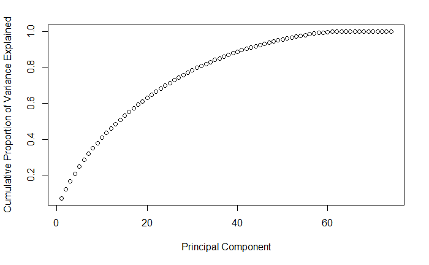

```r
#cumulative scree plot
plot(cumsum(prop_varex), xlab = "Principal Component",
              ylab = "Cumulative Proportion of Variance Explained",
              type = "b")
```

This plot shows that 60 components results in variance close to ~ 98%. Therefore, in this case, we’ll select number of components as 60 [PC1 to PC60] and proceed to the modeling stage. This completes the steps to implement PCA on train data. For modeling, we’ll use these 60 components as predictor variables. See this later in Notebook, after the SVM part.

## LDA

Our next method for analyzing our data in Linear Discriminant Analysis. For this method we need only numeric or integer data types as independent variables and categorical as dependent

```r
library(MASS)
lda_model <- lda(Dependent ~., data=data.train.all)
```

```
variables are collinear
```

```r
# shows you the mean, used for LDA
# head(lda_model$means)

#Predictions on the test data
lda_pred <- predict(object = lda_model, newdata = data.test.all)
lda_pred$class
```

```
 [1] success success success success success fail    fail    success success success success
[12] fail    success success success fail    fail    fail    success success fail    fail
[23] success fail    fail    fail    fail    fail    success fail
Levels: fail success
```

```r
#confusion matrix for lda
library(caret)
confusion.m.lda <- confusionMatrix(lda_pred$class,
                                   data.test.all$Dependent)
confusion.m.lda
```

```
Confusion Matrix and Statistics

          Reference
Prediction fail success
   fail      11       3
   success    4      12

               Accuracy : 0.7667
                 95% CI : (0.5772, 0.9007)
    No Information Rate : 0.5
    P-Value [Acc > NIR] : 0.002611

                  Kappa : 0.5333

 Mcnemar's Test P-Value : 1.000000

            Sensitivity : 0.7333
            Specificity : 0.8000
         Pos Pred Value : 0.7857
         Neg Pred Value : 0.7500
             Prevalence : 0.5000
         Detection Rate : 0.3667
   Detection Prevalence : 0.4667
      Balanced Accuracy : 0.7667

       'Positive' Class : fail
```

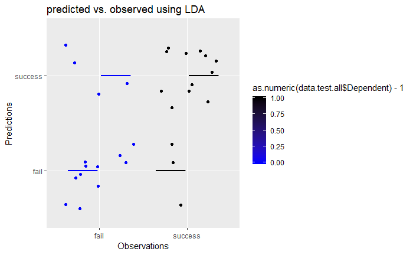

```r
qplot(data.test.all$Dependent,
      lda_pred$class,
      colour= as.numeric(data.test.all$Dependent)-1, geom = c("boxplot", "jitter"),
      main = "predicted vs. observed using LDA",
      xlab = "Observations", ylab = "Predictions") +
  scale_color_gradientn(colors = c("blue", "black"))
```

## KNN

KNN or K-Nearest Neighbor is another learning technique where we try to classify data to a given category. For the new observation x, prediction is made by searching on the whole data set k-nearest neighbors (most similar cases) and on based on this the category of x is determined

```r
# First of all, we need to find the optimal k for our model
# Setting up train controls
repeats = 3
numbers = 10
tunel = 10

x = trainControl(method = "repeatedcv",
                 number = numbers,
                 repeats = repeats,
                 classProbs = TRUE,
                 summaryFunction = twoClassSummary)

model.knn <- train(Dependent~. , data = data.train.all, method = "knn",
                   preProcess = c("center","scale"),
                   trControl = x,
                   metric = "ROC",
                   tuneLength = tunel)

# Summary of model
model.knn
```

```
k-Nearest Neighbors

204 samples
 74 predictor
  2 classes: 'fail', 'success'

Pre-processing: centered (74), scaled (74)
Resampling: Cross-Validated (10 fold, repeated 3 times)
Summary of sample sizes: 184, 184, 183, 184, 184, 184, ...
Resampling results across tuning parameters:

  k   ROC        Sens       Spec
   5  0.6249601  0.6242424  0.5609091
   7  0.6282493  0.6672727  0.5418182
   9  0.6217135  0.6545455  0.5151515
  11  0.6386102  0.6554545  0.5245455
  13  0.6534642  0.7112121  0.5251515
  15  0.6587617  0.7142424  0.5218182
  17  0.6522645  0.6884848  0.5124242
  19  0.6685468  0.7175758  0.5312121
  21  0.6672383  0.7375758  0.5221212
  23  0.6694050  0.7400000  0.4830303

ROC was used to select the optimal model using the largest value.
The final value used for the model was k = 23.
```

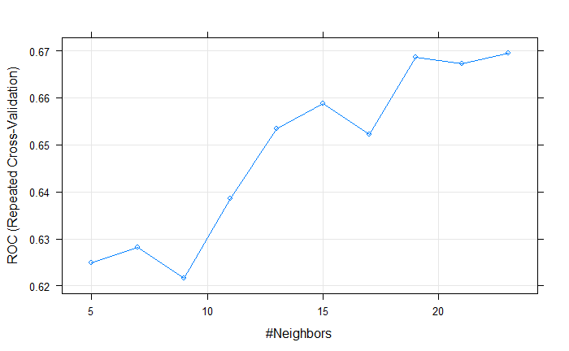

```r
plot(model.knn)
```

```r
# Validation
valid_pred <- predict(model.knn, data.test.all, type = "prob")

# Confusion matrix
predicted.knn <- as.factor(round(valid_pred$success))
levels(predicted.knn) <- c("fail", "success")
confusion.m.knn <- confusionMatrix(predicted.knn,
                                   data.test.all$Dependent)
confusion.m.knn
```

```
Confusion Matrix and Statistics

          Reference
Prediction fail success
   fail      13       8
   success    2       7

               Accuracy : 0.6667
                 95% CI : (0.4719, 0.8271)
    No Information Rate : 0.5
    P-Value [Acc > NIR] : 0.04937

                  Kappa : 0.3333

 Mcnemar's Test P-Value : 0.11385

            Sensitivity : 0.8667
            Specificity : 0.4667
         Pos Pred Value : 0.6190
         Neg Pred Value : 0.7778
             Prevalence : 0.5000
         Detection Rate : 0.4333
   Detection Prevalence : 0.7000
      Balanced Accuracy : 0.6667

       'Positive' Class : fail
```

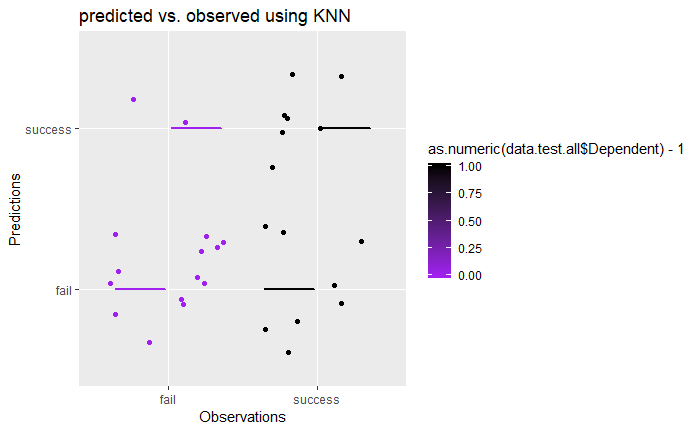

```r
qplot(data.test.all$Dependent,
      predicted.knn,
      colour= as.numeric(data.test.all$Dependent)-1, geom = c("boxplot", "jitter"),
      main = "predicted vs. observed using KNN",
      xlab = "Observations", ylab = "Predictions") +
  scale_color_gradientn(colors = c("purple", "black"))
```

## Model Building

### Logit Models

We build three logistic regression models out of components that we obtained using differend methods for feature selection. By doing this, we’ll able to compare these different approaches.

```r
# fitting stepwise binary logistic regression with logit link function, using features selected with Information value
mod.iv <- step(glm(Dependent~., family = binomial(link=logit),data = train.iv))
```

```
Start:  AIC=276.69
Dependent ~ Company_senior_team_count + Founders_skills_score +
    Company_business_modelB2C + Company_avg_investment_time +
    Company_business_modelB2B + Founders_Marketing_skills_score +
    Founders_Entrepreneurship_skills_score + Company_repeat_investors_count +
    Founders_Sales_skills_score + Company_competitor_count +
    Company_analytics_score + Founders_Data_Science_skills_score +
    Company_1st_investment_time + Company_investor_count_seed +
    Founders_Engineering_skills_score + Founders_Product_Management_skills_score +
    Founders_Business_Strategy_skills_score + Founders_Domain_skills_score +
    Founders_Industry_exposureHigh + Founders_profile_similarityNone +
    Founders_global_exposure

                                           Df Deviance    AIC
- Founders_profile_similarityNone           1   232.69 274.69
- Founders_Industry_exposureHigh            1   232.71 274.71
- Founders_Business_Strategy_skills_score   1   232.72 274.72
- Company_business_modelB2B                 1   232.72 274.73
- Company_repeat_investors_count            1   232.88 274.88
- Founders_Entrepreneurship_skills_score    1   232.88 274.88
- Founders_Data_Science_skills_score        1   232.99 274.99
- Founders_Sales_skills_score               1   233.07 275.07
- Company_avg_investment_time               1   233.14 275.14
- Company_investor_count_seed               1   233.28 275.27
- Founders_skills_score                     1   233.37 275.37
- Founders_global_exposure                  1   233.38 275.38
- Founders_Product_Management_skills_score  1   233.42 275.42
- Founders_Engineering_skills_score         1   233.51 275.51
- Founders_Marketing_skills_score           1   233.63 275.63
- Company_1st_investment_time               1   233.66 275.66
- Company_business_modelB2C                 1   233.94 275.94
<none>                                          232.69 276.69
- Founders_Domain_skills_score              1   234.74 276.74
- Company_competitor_count                  1   234.96 276.96
- Company_analytics_score                   1   235.32 277.32
- Company_senior_team_count                 1   241.06 283.06

Step:  AIC=274.69
Dependent ~ Company_senior_team_count + Founders_skills_score +
    Company_business_modelB2C + Company_avg_investment_time +
```

[output cut: 369 more lines]

```
- Company_competitor_count      1   242.67 252.67
- Company_analytics_score       1   243.69 253.69
- Company_business_modelB2C     1   248.85 258.85
- Company_senior_team_count     1   253.77 263.77

Step:  AIC=251.08
Dependent ~ Company_senior_team_count + Company_business_modelB2C +
    Company_competitor_count + Company_analytics_score

                            Df Deviance    AIC
<none>                           241.08 251.08
- Company_competitor_count   1   244.23 252.23
- Company_analytics_score    1   244.83 252.83
- Company_business_modelB2C  1   251.53 259.54
- Company_senior_team_count  1   254.87 262.87
```

```r
# from randomForest
mod.varimp <- step(glm(Dependent~., family = binomial(link=logit),data = train.varimp))
```

```
Start:  AIC=263.65
Dependent ~ Company_senior_team_count + Founders_Popularity +
    Founders_publicationsFew + Founders_Data_Science_skills_score +
    Company_crowdfunding + Company_subscription_offering + Company_senior_team_count.1 +
    Founders_skills_score + Founders_Entrepreneurship_skills_score +
    Founders_Engineering_skills_score + Founders_Marketing_skills_score +
    Company_competitor_count + Company_1st_investment_time +
    Company_avg_investment_time


Step:  AIC=263.65
Dependent ~ Company_senior_team_count + Founders_Popularity +
    Founders_publicationsFew + Founders_Data_Science_skills_score +
    Company_crowdfunding + Company_subscription_offering + Founders_skills_score +
    Founders_Entrepreneurship_skills_score + Founders_Engineering_skills_score +
    Founders_Marketing_skills_score + Company_competitor_count +
    Company_1st_investment_time + Company_avg_investment_time

                                         Df Deviance    AIC
- Company_avg_investment_time             1   235.83 261.83
- Company_subscription_offering           1   235.85 261.85
- Founders_skills_score                   1   236.10 262.10
- Founders_Entrepreneurship_skills_score  1   236.18 262.18
- Founders_Marketing_skills_score         1   236.21 262.21
- Company_competitor_count                1   237.49 263.49
<none>                                        235.65 263.65
- Founders_Engineering_skills_score       1   237.85 263.85
- Company_1st_investment_time             1   238.04 264.04
- Founders_Popularity                     1   238.10 264.10
- Founders_publicationsFew                1   239.47 265.46
- Founders_Data_Science_skills_score      1   240.11 266.11
- Company_crowdfunding                    1   242.67 268.67
- Company_senior_team_count               1   247.13 273.13

Step:  AIC=261.83
Dependent ~ Company_senior_team_count + Founders_Popularity +
    Founders_publicationsFew + Founders_Data_Science_skills_score +
    Company_crowdfunding + Company_subscription_offering + Founders_skills_score +
    Founders_Entrepreneurship_skills_score + Founders_Engineering_skills_score +
    Founders_Marketing_skills_score + Company_competitor_count +
```

[output cut: 78 more lines]

```
Dependent ~ Company_senior_team_count + Founders_Popularity +
    Founders_publicationsFew + Founders_Data_Science_skills_score +
    Company_crowdfunding + Founders_Engineering_skills_score +
    Company_competitor_count + Company_1st_investment_time

                                     Df Deviance    AIC
<none>                                    237.10 255.10
- Founders_Engineering_skills_score   1   239.40 255.40
- Founders_Popularity                 1   239.44 255.44
- Company_competitor_count            1   239.47 255.47
- Company_1st_investment_time         1   239.97 255.97
- Founders_publicationsFew            1   240.83 256.83
- Founders_Data_Science_skills_score  1   241.55 257.55
- Company_crowdfunding                1   244.85 260.85
- Company_senior_team_count           1   248.95 264.95
```

```r
# from mars
mod.mars <- step(glm(Dependent~., family = binomial(link=logit),data = train.mars))
```

```
Start:  AIC=255.64
Dependent ~ Company_senior_team_count + Company_business_modelB2C +
    Company_competitor_count + Company_analytics_score + Founders_Marketing_skills_score +
    Company_crowdfunding + Company_investor_count_seed + Founders_skills_score +
    Founders_Domain_skills_score + Founders_Entrepreneurship_skills_score +
    Company_avg_investment_time + Company_LocationEurope + Company_crowdsourcing

                                         Df Deviance    AIC
- Company_avg_investment_time             1   227.65 253.65
- Founders_Marketing_skills_score         1   227.85 253.85
- Founders_Entrepreneurship_skills_score  1   227.92 253.92
- Founders_skills_score                   1   228.12 254.12
- Company_investor_count_seed             1   228.31 254.31
- Company_analytics_score                 1   228.79 254.79
- Founders_Domain_skills_score            1   228.84 254.84
- Company_crowdsourcing                   1   229.05 255.05
<none>                                        227.64 255.64
- Company_LocationEurope                  1   230.83 256.83
- Company_competitor_count                1   232.99 258.99
- Company_crowdfunding                    1   234.12 260.12
- Company_business_modelB2C               1   238.61 264.61
- Company_senior_team_count               1   241.99 267.99

Step:  AIC=253.64
Dependent ~ Company_senior_team_count + Company_business_modelB2C +
    Company_competitor_count + Company_analytics_score + Founders_Marketing_skills_score +
    Company_crowdfunding + Company_investor_count_seed + Founders_skills_score +
    Founders_Domain_skills_score + Founders_Entrepreneurship_skills_score +
    Company_LocationEurope + Company_crowdsourcing

                                         Df Deviance    AIC
- Founders_Marketing_skills_score         1   227.85 251.85
- Founders_Entrepreneurship_skills_score  1   227.92 251.92
- Founders_skills_score                   1   228.12 252.12
- Company_investor_count_seed             1   228.31 252.31
- Company_analytics_score                 1   228.81 252.81
- Founders_Domain_skills_score            1   228.85 252.85
- Company_crowdsourcing                   1   229.05 253.05
<none>                                        227.65 253.65
- Company_LocationEurope                  1   230.84 254.84
```

[output cut: 104 more lines]

```
- Company_crowdfunding       1   238.38 250.38
- Company_business_modelB2C  1   243.16 255.16
- Company_senior_team_count  1   247.06 259.06

Step:  AIC=244.87
Dependent ~ Company_senior_team_count + Company_business_modelB2C +
    Company_competitor_count + Company_crowdfunding + Company_LocationEurope

                            Df Deviance    AIC
<none>                           232.87 244.87
- Company_LocationEurope     1   237.12 247.12
- Company_competitor_count   1   238.76 248.76
- Company_crowdfunding       1   240.85 250.85
- Company_business_modelB2C  1   245.16 255.16
- Company_senior_team_count  1   250.37 260.37
```

```r
summary(mod.iv)
```

```
Call:
glm(formula = Dependent ~ Company_senior_team_count + Company_business_modelB2C +
    Company_competitor_count + Company_analytics_score, family = binomial(link = logit),
    data = train.iv)

Deviance Residuals:
    Min       1Q   Median       3Q      Max
-2.1794  -0.9181  -0.3761   1.0046   2.0113

Coefficients:
                          Estimate Std. Error z value Pr(>|z|)
(Intercept)               -0.90223    0.39040  -2.311 0.020829 *
Company_senior_team_count  0.24843    0.07067   3.516 0.000439 ***
Company_business_modelB2C -1.17857    0.37846  -3.114 0.001845 **
Company_competitor_count  -0.08595    0.05285  -1.626 0.103877
Company_analytics_score    0.28901    0.15039   1.922 0.054630 .
---
Signif. codes:  0 ‘***’ 0.001 ‘**’ 0.01 ‘*’ 0.05 ‘.’ 0.1 ‘ ’ 1

(Dispersion parameter for binomial family taken to be 1)

    Null deviance: 282.78  on 203  degrees of freedom
Residual deviance: 241.08  on 199  degrees of freedom
AIC: 251.08

Number of Fisher Scoring iterations: 4
```

```r
summary(mod.varimp)
```

```
Call:
glm(formula = Dependent ~ Company_senior_team_count + Founders_Popularity +
    Founders_publicationsFew + Founders_Data_Science_skills_score +
    Company_crowdfunding + Founders_Engineering_skills_score +
    Company_competitor_count + Company_1st_investment_time, family = binomial(link = logit),
    data = train.varimp)

Deviance Residuals:
    Min       1Q   Median       3Q      Max
-1.9310  -0.9179  -0.4528   0.9655   2.2781

Coefficients:
                                    Estimate Std. Error z value Pr(>|z|)
(Intercept)                        -2.327812   0.567169  -4.104 4.06e-05 ***
Company_senior_team_count           0.239863   0.072790   3.295 0.000983 ***
Founders_Popularity                 0.659733   0.438531   1.504 0.132474
Founders_publicationsFew            0.877554   0.462631   1.897 0.057844 .
Founders_Data_Science_skills_score  0.033951   0.017120   1.983 0.047354 *
Company_crowdfunding                2.129550   0.868204   2.453 0.014174 *
Founders_Engineering_skills_score   0.010449   0.006889   1.517 0.129336
Company_competitor_count           -0.073346   0.051251  -1.431 0.152400
Company_1st_investment_time         0.015826   0.009827   1.610 0.107316
---
Signif. codes:  0 ‘***’ 0.001 ‘**’ 0.01 ‘*’ 0.05 ‘.’ 0.1 ‘ ’ 1

(Dispersion parameter for binomial family taken to be 1)

    Null deviance: 282.78  on 203  degrees of freedom
Residual deviance: 237.10  on 195  degrees of freedom
AIC: 255.1

Number of Fisher Scoring iterations: 4
```

```r
summary(mod.mars)
```

```
Call:
glm(formula = Dependent ~ Company_senior_team_count + Company_business_modelB2C +
    Company_competitor_count + Company_crowdfunding + Company_LocationEurope,
    family = binomial(link = logit), data = train.mars)

Deviance Residuals:
    Min       1Q   Median       3Q      Max
-2.0468  -0.9499  -0.2315   0.9652   2.2720

Coefficients:
                          Estimate Std. Error z value Pr(>|z|)
(Intercept)               -0.97241    0.40141  -2.422 0.015415 *
Company_senior_team_count  0.29358    0.07535   3.896 9.78e-05 ***
Company_business_modelB2C -1.32832    0.39901  -3.329 0.000871 ***
Company_competitor_count  -0.13049    0.05889  -2.216 0.026691 *
Company_crowdfunding       2.21748    0.88315   2.511 0.012043 *
Company_LocationEurope     0.91696    0.45274   2.025 0.042830 *
---
Signif. codes:  0 ‘***’ 0.001 ‘**’ 0.01 ‘*’ 0.05 ‘.’ 0.1 ‘ ’ 1

(Dispersion parameter for binomial family taken to be 1)

    Null deviance: 282.78  on 203  degrees of freedom
Residual deviance: 232.87  on 198  degrees of freedom
AIC: 244.87

Number of Fisher Scoring iterations: 4
```

```r
#predict
iv.pred <- predict(object=mod.iv, newdata=data.test.all, type="response")
iv.pred <- as.factor(round(iv.pred))
levels(iv.pred) <- c("fail", "success")

varimp.pred <- predict(object=mod.varimp, newdata=data.test.all, type="response")
varimp.pred <- as.factor(round(varimp.pred))
levels(varimp.pred) <- c("fail", "success")

#confusion matrix for iv
confusion.m.iv <- confusionMatrix(iv.pred, data.test.all$Dependent)
confusion.m.iv
```

```
Confusion Matrix and Statistics

          Reference
Prediction fail success
   fail      12       4
   success    3      11

               Accuracy : 0.7667
                 95% CI : (0.5772, 0.9007)
    No Information Rate : 0.5
    P-Value [Acc > NIR] : 0.002611

                  Kappa : 0.5333

 Mcnemar's Test P-Value : 1.000000

            Sensitivity : 0.8000
            Specificity : 0.7333
         Pos Pred Value : 0.7500
         Neg Pred Value : 0.7857
             Prevalence : 0.5000
         Detection Rate : 0.4000
   Detection Prevalence : 0.5333
      Balanced Accuracy : 0.7667

       'Positive' Class : fail
```

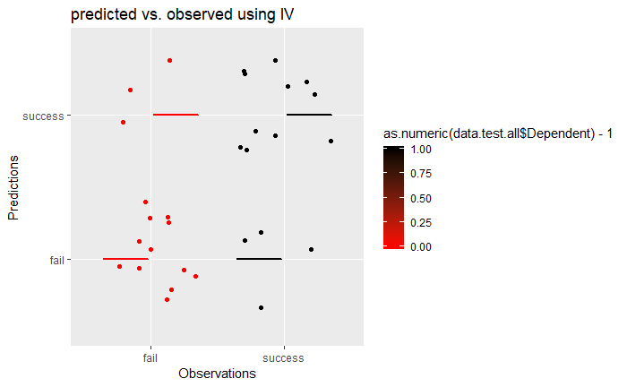

```r
qplot(data.test.all$Dependent,
      iv.pred,
      colour= as.numeric(data.test.all$Dependent)-1, geom = c("boxplot",
                                                              "jitter"),
      main = "predicted vs. observed using IV",
      xlab = "Observations", ylab = "Predictions") +
  scale_color_gradientn(colors = c("red", "black"))
```

```r
#confusion matrix for varimp
confusion.m.varimp <- confusionMatrix(varimp.pred, data.test.all$Dependent)
confusion.m.varimp
```

```
Confusion Matrix and Statistics

          Reference
Prediction fail success
   fail      11       4
   success    4      11

               Accuracy : 0.7333
                 95% CI : (0.5411, 0.8772)
    No Information Rate : 0.5
    P-Value [Acc > NIR] : 0.008062

                  Kappa : 0.4667

 Mcnemar's Test P-Value : 1.000000

            Sensitivity : 0.7333
            Specificity : 0.7333
         Pos Pred Value : 0.7333
         Neg Pred Value : 0.7333
             Prevalence : 0.5000
         Detection Rate : 0.3667
   Detection Prevalence : 0.5000
      Balanced Accuracy : 0.7333

       'Positive' Class : fail
```

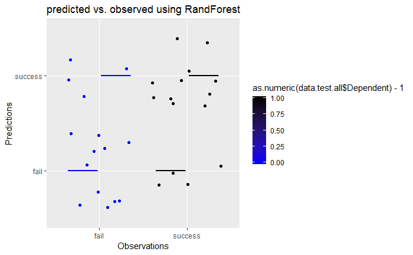

```r
qplot(data.test.all$Dependent,
      varimp.pred,
      colour= as.numeric(data.test.all$Dependent)-1, geom = c("boxplot", "jitter"),
      main = "predicted vs. observed using RandForest",
      xlab = "Observations", ylab = "Predictions") +
  scale_color_gradientn(colors = c("blue", "black"))
```

```r
# model fit (Hosmer and Lemeshow goodness of fit (GOF) test)
library(ResourceSelection)
hoslem.test(train_new$Dependent,mod.iv$fitted.values, g=10)
```

```
    Hosmer and Lemeshow goodness of fit (GOF) test

data:  train_new$Dependent, mod.iv$fitted.values
X-squared = 10.236, df = 8, p-value = 0.2488
```

### Support Verctor Machine

We take the dataframe with the features selected using Information Value algorithm and use these selected features to build an SVM model for predicting binary outcome.

```r
train.iv
```

|  | Dependent | Company_senior_team_count | Founders_skills_score | Company_business_modelB2C | Company_avg_investment_time | Company_business_modelB2B | Founders_Marketing_skills_score | Founders_Entrepreneurship_skills_score | Company_repeat_investors_count | Founders_Sales_skills_score | Company_competitor_count | Company_analytics_score | Founders_Data_Science_skills_score | Company_1st_investment_time | Company_investor_count_seed | Founders_Engineering_skills_score | Founders_Product_Management_skills_score | Founders_Business_Strategy_skills_score | Founders_Domain_skills_score | Founders_Industry_exposureHigh | Founders_profile_similarityNone | Founders_global_exposure |
| --- | --- | --- | --- | --- | --- | --- | --- | --- | --- | --- | --- | --- | --- | --- | --- | --- | --- | --- | --- | --- | --- | --- |
| 1 | success | 7 | 36.0 | 0 | 7.3444 | 1 | 0.0000 | 9.4017 | 0 | 0.0000 | 0 | 1 | 3.8462 | 2 | 15 | 57.4786 | 9.4017 | 17.0940 | 2.7778 | 0 | 0 | 1 |
| 2 | success | 8 | 23.0 | 0 | 9.8222 | 1 | 0.0000 | 0.0000 | 0 | 0.0000 | 0 | 0 | 0.0000 | 13 | 7 | 0.0000 | 0.0000 | 0.0000 | 0.0000 | 0 | 0 | 1 |
| 3 | success | 4 | 25.0 | 0 | 9.3222 | 0 | 15.6250 | 6.2500 | 2 | 3.1250 | 0 | 0 | 3.1250 | 12 | 2 | 3.1250 | 3.1250 | 6.2500 | 0.0000 | 0 | 0 | 1 |
| 4 | success | 4 | 4.5 | 0 | 6.4000 | 1 | 0.0000 | 0.0000 | 0 | 0.0000 | 0 | 2 | 0.0000 | 20 | 0 | 10.1120 | 0.0000 | 0.0000 | 0.0000 | 0 | 0 | 1 |
| 5 | success | 2 | 48.0 | 0 | 12.0000 | 1 | 5.7190 | 8.3333 | 0 | 2.7778 | 0 | 0 | 0.0000 | 18 | 13 | 46.7320 | 2.7778 | 19.7712 | 0.0000 | 1 | 0 | 1 |
| 6 | success | 8 | 14.5 | 0 | 2.6667 | 1 | 0.0000 | 3.8462 | 0 | 3.8462 | 4 | 0 | 3.8462 | 24 | 0 | 26.9231 | 0.0000 | 7.6923 | 0.0000 | 1 | 1 | 1 |
| 7 | success | 6 | 20.5 | 0 | 7.3333 | 1 | 16.6667 | 8.3333 | 0 | 4.1667 | 0 | 0 | 12.5000 | 14 | 0 | 50.0000 | 4.1667 | 4.1667 | 0.0000 | 0 | 0 | 1 |
| 8 | success | 8 | 21.0 | 0 | 8.0000 | 1 | 0.0000 | 11.1111 | 0 | 11.1111 | 0 | 1 | 11.1111 | 38 | 0 | 5.5556 | 0.0000 | 27.7778 | 5.5556 | 0 | 0 | 1 |
| 9 | success | 7 | 12.0 | 0 | 11.0667 | 1 | 0.0000 | 8.3333 | 2 | 0.0000 | 0 | 1 | 0.0000 | 3 | 0 | 58.3333 | 0.0000 | 25.0000 | 8.3333 | 1 | 1 | 1 |
| 10 | success | 8 | 4.5 | 0 | 12.6167 | 1 | 0.0000 | 20.0000 | 2 | 0.0000 | 0 | 3 | 0.0000 | 30 | 0 | 20.0000 | 0.0000 | 20.0000 | 0.0000 | 0 | 0 | 1 |

[output cut: 194 more lines]

```r
library('e1071')

# building SVM model from the variables obtained after feature selection using IV.

model.svm <- svm(Dependent ~  .,
              data = train.iv, probability = TRUE, type='nu-classification')


print(model.svm)
```

```
Call:
svm(formula = Dependent ~ ., data = train.iv, probability = TRUE, type = "nu-classification")


Parameters:
   SVM-Type:  nu-classification
 SVM-Kernel:  radial
      gamma:  0.04761905
         nu:  0.5

Number of Support Vectors:  171
```

```r
library(caret)
confusionMatrix(as.factor(train.iv$Dependent), predict(model.svm))
```

```
Confusion Matrix and Statistics

          Reference
Prediction fail success
   fail      98       5
   success    5      96

               Accuracy : 0.951
                 95% CI : (0.9117, 0.9762)
    No Information Rate : 0.5049
    P-Value [Acc > NIR] : <2e-16

                  Kappa : 0.902

 Mcnemar's Test P-Value : 1

            Sensitivity : 0.9515
            Specificity : 0.9505
         Pos Pred Value : 0.9515
         Neg Pred Value : 0.9505
             Prevalence : 0.5049
         Detection Rate : 0.4804
   Detection Prevalence : 0.5049
      Balanced Accuracy : 0.9510

       'Positive' Class : fail
```

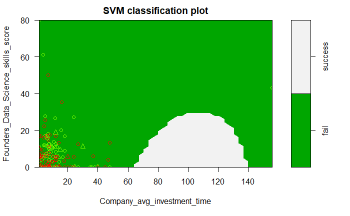

```r
#plot model
plot(model.svm, data.train.all, Founders_Data_Science_skills_score ~ Company_avg_investment_time,
     svSymbol = 1, dataSymbol = 2, symbolPalette = rainbow(4),
color.palette = terrain.colors)
```

### SVM on principal components

```r
#add a training set with principal components
train.data <- data.frame(Dependent = train_new$Dependent, prin_comp$x)

#we are interested in first 60 PCAs
train.data <- train.data[,1:61]

#transform test into PCA
test.data <- predict(prin_comp, newdata = pca.test)
test.data <- as.data.frame(test.data)

#select the first 60 components
test.data <- test.data[,1:61]


library('e1071')

# building SVM model from the variables obtained after feature selection using PCA.
model.svm.pca <- svm(Dependent ~ .,data = train.data, probability = TRUE, type='nu-classification')

#make prediction on test data
svm.prediction <- predict(model.svm.pca, test.data, type = "class")


confusionMatrix(as.factor(test_new$Dependent), svm.prediction)
```

```
Confusion Matrix and Statistics

          Reference
Prediction  0  1
         0 10  5
         1  2 13

               Accuracy : 0.7667
                 95% CI : (0.5772, 0.9007)
    No Information Rate : 0.6
    P-Value [Acc > NIR] : 0.04352

                  Kappa : 0.5333

 Mcnemar's Test P-Value : 0.44969

            Sensitivity : 0.8333
            Specificity : 0.7222
         Pos Pred Value : 0.6667
         Neg Pred Value : 0.8667
             Prevalence : 0.4000
         Detection Rate : 0.3333
   Detection Prevalence : 0.5000
      Balanced Accuracy : 0.7778

       'Positive' Class : 0
```

## Predicting test score and model evaluation

```r
# Prediction on test set of CAX

# for PCA model
# test
# x <- subset(test, select = -Dependent)
# pca.test <- dummy.data.frame(subset(test, select = -Dependent), names = result$my.fct.names)
#
# #transform test into PCA
# test.data <- predict(prin_comp, newdata = pca.test)
# test.data <- as.data.frame(test.data)
#
# #select the first 60 components
# x <- test.data[,1:61]
#
#
# pred_CAX <- predict(model.svm.pca, newdata=x)


iv.pred.final <- predict(object=mod.iv, newdata=data.test.final, type="response")
iv.pred.final
```

```
       235        236        237        238        239        240        241        242
0.17023670 0.47990350 0.47094170 0.53296814 0.69778368 0.71462081 0.30255697 0.52285421
       243        244        245        246        247        248        249        250
0.72282475 0.52285421 0.59171419 0.47870860 0.52285421 0.17023670 0.34213262 0.08200307
       251        252        253        254        255        256        257        258
0.40002128 0.53296814 0.51930450 0.18499234 0.52285421 0.88647684 0.88883624 0.25216596
       259        260        261        262        263        264        265        266
0.54305504 0.52285421 0.40002128 0.37211493 0.52285421 0.46084336 0.68976494 0.16627511
       267        268        269        270        271        272        273        274
0.12804745 0.13572598 0.13795509 0.40002128 0.67042068 0.56082668 0.40181946 0.67042068
       275        276        277        278        279        280        281        282
0.72282475 0.46084336 0.29882712 0.33604275 0.54962270 0.26755538 0.38694213 0.72996635
       283        284        285        286        287        288        289        290
0.91397246 0.50138140 0.81627464 0.58300494 0.47094170 0.71462081 0.69477566 0.15330320
       291        292        293        294        295        296        297        298
0.73606179 0.82949488 0.20824741 0.30181600 0.53296814 0.72282475 0.17023670 0.40002128
       299        300        301        302        303        304        305        306
0.08061177 0.34213262 0.40002128 0.58416844 0.17023670 0.35955724 0.17023670 0.13683672
       307        308        309        310        311        312        313        314
0.55077313 0.07991517 0.47990350 0.12699756 0.38918298 0.54305504 0.37736026 0.42034162
```

```r
submit_iv.pred <- cbind(test$CAX_ID, round(iv.pred.final))
colnames(submit_iv.pred)<- c("CAX_ID", "Dependent")
write.csv(submit_iv.pred,"PredictionsIV.csv",row.names=F)


varimp.pred.final <- predict(object=mod.varimp, newdata=data.test.final, type="response")
varimp.pred.final
```

```
       235        236        237        238        239        240        241        242
0.28188262 0.30164127 0.60748733 0.55651248 0.79630392 0.49124383 0.43468105 0.45750992
       243        244        245        246        247        248        249        250
0.59639969 0.43064241 0.43163662 0.24815121 0.39909616 0.26306536 0.54476006 0.06557464
       251        252        253        254        255        256        257        258
0.27441943 0.52173945 0.35174614 0.21014793 0.66658634 0.77098953 0.91036286 0.39183836
       259        260        261        262        263        264        265        266
0.27112679 0.45433738 0.30639992 0.51849205 0.71101155 0.48216857 0.80689779 0.30336908
       267        268        269        270        271        272        273        274
0.15314157 0.47887224 0.46525779 0.44267148 0.74727879 0.64312882 0.35179654 0.68954313
       275        276        277        278        279        280        281        282
0.49302809 0.34827549 0.34570814 0.36333345 0.34398492 0.30875068 0.19740255 0.59533451
       283        284        285        286        287        288        289        290
0.94602017 0.45246100 0.93976202 0.31336136 0.56795502 0.40656731 0.49189315 0.48094326
       291        292        293        294        295        296        297        298
0.77323867 0.78132513 0.36244914 0.92930664 0.83843842 0.94601499 0.32105791 0.13796911
       299        300        301        302        303        304        305        306
0.08721229 0.19585723 0.16000670 0.55335164 0.48284794 0.22442311 0.33085877 0.26595294
       307        308        309        310        311        312        313        314
0.23274883 0.15315416 0.39405887 0.23064100 0.40072441 0.36183366 0.31574953 0.16254452
```

```r
submit_varimp.pred <- cbind(test$CAX_ID, round(varimp.pred.final))
colnames(submit_varimp.pred)<- c("CAX_ID", "Dependent")
write.csv(submit_varimp.pred,"PredictionsVARIMP.csv",row.names=F)


knn.pred.final <- predict(model.knn, data.test.final, type = "prob")
knn.pred.final$success
```

```
 [1] 0.3913043 0.4347826 0.6086957 0.6086957 0.6956522 0.7391304 0.4347826 0.3478261 0.3913043
[10] 0.3043478 0.4347826 0.4782609 0.4782609 0.3913043 0.5217391 0.5217391 0.3043478 0.4782609
[19] 0.3750000 0.3478261 0.6521739 0.6086957 0.6086957 0.4347826 0.6086957 0.6086957 0.5217391
[28] 0.4782609 0.7826087 0.6086957 0.6086957 0.3043478 0.3913043 0.2608696 0.2608696 0.3478261
[37] 0.5652174 0.5217391 0.5652174 0.7826087 0.5217391 0.3913043 0.2173913 0.2173913 0.3043478
[46] 0.3913043 0.4347826 0.5217391 0.7391304 0.3478261 0.4782609 0.4347826 0.4347826 0.6086957
[55] 0.6521739 0.6956522 0.5217391 0.4782609 0.2173913 0.4782609 0.6521739 0.5217391 0.4347826
[64] 0.3478261 0.4347826 0.3913043 0.3478261 0.4782609 0.2608696 0.2173913 0.3043478 0.3043478
[73] 0.4347826 0.3043478 0.5000000 0.4782609 0.5217391 0.3478261 0.3478261 0.5217391
```

```r
submit_knn.pred <- cbind(test$CAX_ID, round(knn.pred.final$success))
colnames(submit_knn.pred)<- c("CAX_ID", "Dependent")
write.csv(submit_knn.pred,"PredictionsKNN.csv",row.names=F)

lda_pred.final <- predict(object = lda_model, newdata = data.test.final)
lda_pred.final$class
```

```
 [1] fail    fail    success fail    success success success success success fail    fail
[12] success fail    fail    success fail    fail    fail    fail    success success success
[23] success fail    fail    success success success success success success fail    fail
[34] fail    fail    success success success fail    success success success fail    fail
[45] fail    fail    fail    success success fail    success fail    success success success
[56] success success success fail    fail    success success fail    fail    fail    success
[67] fail    success fail    fail    fail    fail    success fail    success fail    success
[78] success success fail
Levels: fail success
```

```r
submit_lda.pred <- cbind(test$CAX_ID, as.numeric(lda_pred.final$class)-1)
colnames(submit_lda.pred)<- c("CAX_ID", "Dependent")
write.csv(submit_lda.pred,"PredictionsLDA.csv",row.names=F)
```